# Python Project

# honey_production_data.

# Domain: Sales predict

# SUBMITTED BY;

# Sutharsan M

# 1. Import required libraries and read the dataset.

```python
#required libraries which I used for EDA
import pandas as pd
import numpy as np
import matplotlib.pyplot as plt
import seaborn as sns
import warnings

# Suppress warnings for cleaner output
warnings.filterwarnings("ignore")
```

```python
# feed the file data what I need for my analyse
hp = pd.read_csv('honeyproduction.csv')
hp
```

|  | state | numcol | yieldpercol | totalprod | stocks | priceperlb | prodvalue | year |
| --- | --- | --- | --- | --- | --- | --- | --- | --- |
| 0 | AL | 16000.0 | 71 | 1136000.0 | 159000.0 | 0.72 | 818000.0 | 1998 |
| 1 | AZ | 55000.0 | 60 | 3300000.0 | 1485000.0 | 0.64 | 2112000.0 | 1998 |
| 2 | AR | 53000.0 | 65 | 3445000.0 | 1688000.0 | 0.59 | 2033000.0 | 1998 |
| 3 | CA | 450000.0 | 83 | 37350000.0 | 12326000.0 | 0.62 | 23157000.0 | 1998 |
| 4 | CO | 27000.0 | 72 | 1944000.0 | 1594000.0 | 0.70 | 1361000.0 | 1998 |
| ... | ... | ... | ... | ... | ... | ... | ... | ... |
| 621 | VA | 4000.0 | 41 | 164000.0 | 23000.0 | 3.77 | 618000.0 | 2012 |
| 622 | WA | 62000.0 | 41 | 2542000.0 | 1017000.0 | 2.38 | 6050000.0 | 2012 |
| 623 | WV | 6000.0 | 48 | 288000.0 | 95000.0 | 2.91 | 838000.0 | 2012 |
| 624 | WI | 60000.0 | 69 | 4140000.0 | 1863000.0 | 2.05 | 8487000.0 | 2012 |
| 625 | WY | 50000.0 | 51 | 2550000.0 | 459000.0 | 1.87 | 4769000.0 | 2012 |

626 rows × 8 columns

This script imports the "pandas","Numpy","matplotlib.pyplot","seaborn","warnings"- library, reads the dataset from the CSV file, and displays the dataset.

# 2. Check the first few samples, shape, info of the data and try to familiarize yourself with different features.

```python
# Display the first few samples
hp.head()
```

|  | state | numcol | yieldpercol | totalprod | stocks | priceperlb | prodvalue | year |
| --- | --- | --- | --- | --- | --- | --- | --- | --- |
| 0 | AL | 16000.0 | 71 | 1136000.0 | 159000.0 | 0.72 | 818000.0 | 1998 |
| 1 | AZ | 55000.0 | 60 | 3300000.0 | 1485000.0 | 0.64 | 2112000.0 | 1998 |
| 2 | AR | 53000.0 | 65 | 3445000.0 | 1688000.0 | 0.59 | 2033000.0 | 1998 |
| 3 | CA | 450000.0 | 83 | 37350000.0 | 12326000.0 | 0.62 | 23157000.0 | 1998 |
| 4 | CO | 27000.0 | 72 | 1944000.0 | 1594000.0 | 0.70 | 1361000.0 | 1998 |

```python
# Display the shape of the data
print("Shape of the data:", hp.shape)
```

```
Shape of the data: (626, 8)
```

```python
# Get information about the data
print(hp.info())
```

```
<class 'pandas.core.frame.DataFrame'>
RangeIndex: 626 entries, 0 to 625
Data columns (total 8 columns):
 #   Column       Non-Null Count  Dtype
---  ------       --------------  -----
 0   state        626 non-null    object
 1   numcol       626 non-null    float64
 2   yieldpercol  626 non-null    int64
 3   totalprod    626 non-null    float64
 4   stocks       626 non-null    float64
 5   priceperlb   626 non-null    float64
 6   prodvalue    626 non-null    float64
 7   year         626 non-null    int64
dtypes: float64(5), int64(2), object(1)
memory usage: 39.3+ KB
None
```

1. It contains 626 rows and 8 columns.
2. The columns in the dataset are as follows:
- state: Categorical data (object type) representing the abbreviation of the state.
- numcol: Numeric data (float64) representing the number of honey-producing colonies.
- yieldpercol: Numeric data (int64) representing the yield per honey-producing colony.
- totalprod: Numeric data (float64) representing the total honey production in pounds.
- stocks: Numeric data (float64) representing the stocks of honey in pounds.
- priceperlb: Numeric data (float64) representing the price per pound of honey.
- prodvalue: Numeric data (float64) representing the value of honey production.
- year: Numeric data (int64) representing the year in which the data was recorded.

# 3. Display the percentage distribution of the data in each year using the pie chart.

```python
# Group the data by year and calculate the sum of totalprod for each year
yearly_totalprod = hp.groupby('year')['totalprod'].sum()
```

```python
yearly_totalprod
```

```
year
1998    219519000.0
1999    202387000.0
2000    219558000.0
2001    185748000.0
2002    171265000.0
2003    181372000.0
2004    182729000.0
2005    173969000.0
2006    154238000.0
2007    147621000.0
2008    162972000.0
2009    145068000.0
2010    175294000.0
2011    147201000.0
2012    140907000.0
Name: totalprod, dtype: float64
```

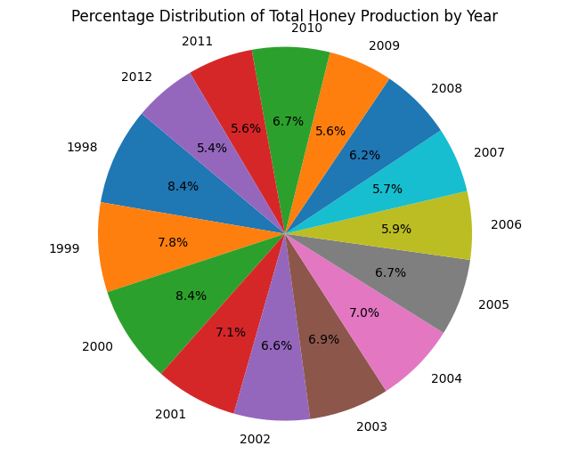

```python
# Create a pie chart
plt.figure(figsize=(8,6))
plt.pie(yearly_totalprod, labels=yearly_totalprod.index, autopct='%1.1f%%', startangle=140)
plt.title('Percentage Distribution of Total Honey Production by Year')
plt.axis('equal')  # Equal aspect ratio ensures that the pie is drawn as a circle.

# Show the pie chart
plt.show()
```